# CaratWiseModel

Zackery Fleming, Jake Compton, Cristian Castro

2023-10-26

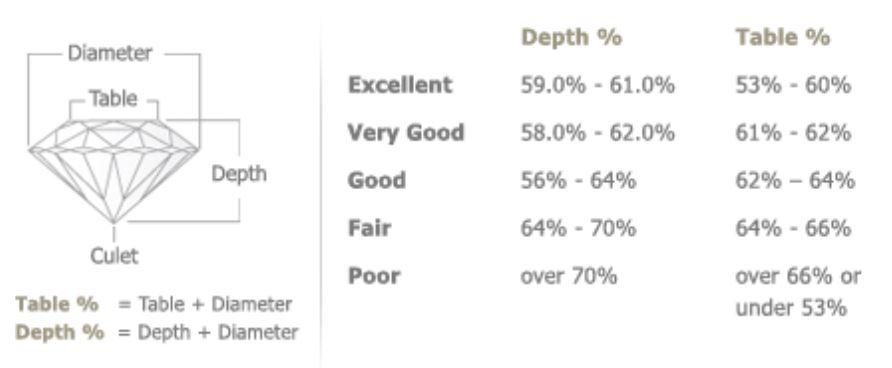

Diamond Dimensions

## Introduction

The goal of our project is to predict the price of diamonds within 80% to 90% accuracy of the true price. The audience that is most interested in our work consists of the buyers and sellers of diamonds. The dataset that we use in this project comes from Kaggle. We begin by exploring and analyzing the dataset. We then move onto data wrangling, testing models, and finally our results. We conclude with an explanation of our findings.

## Explanation of the Diamond Dataset

## Importaing Libraries and Data

```r
library(tidyverse)  # data manipulation and wrangling
```

```r
library(ggplot2)    # graphs and charts for data visualization
library(gridExtra)  # showing multiple plots next one another
library(reshape2)   # for reshaping matrices, for correlation matrix
diamonds_raw <- read_csv("diamonds.csv", col_names = TRUE, col_types = "ncccnnnnnn")
```

## Data Visualization

Now its a good time to look at the dataset, to see what we can expect. Charts and graphs is a great way to visually understand the dataset.

### Data Summary

Let’s start with simply looking at the first few records, to get an idea of what we are looking at.

```r
head(diamonds_raw)
```

```
## # A tibble: 6 × 10
##   carat cut       color clarity depth table price     x     y     z
##   <dbl> <chr>     <chr> <chr>   <dbl> <dbl> <dbl> <dbl> <dbl> <dbl>
## 1  0.23 Ideal     E     SI2      61.5    55   326  3.95  3.98  2.43
## 2  0.21 Premium   E     SI1      59.8    61   326  3.89  3.84  2.31
## 3  0.23 Good      E     VS1      56.9    65   327  4.05  4.07  2.31
## 4  0.29 Premium   I     VS2      62.4    58   334  4.2   4.23  2.63
## 5  0.31 Good      J     SI2      63.3    58   335  4.34  4.35  2.75
## 6  0.24 Very Good J     VVS2     62.8    57   336  3.94  3.96  2.48
```

Now, let’s look at a summary of the dataset, to see the ranges and medians of the columns, as well as if there are any missing/NULL values.

```r
summary(diamonds_raw)
```

```
##      carat            cut               color             clarity
##  Min.   :0.2000   Length:53940       Length:53940       Length:53940
##  1st Qu.:0.4000   Class :character   Class :character   Class :character
##  Median :0.7000   Mode  :character   Mode  :character   Mode  :character
##  Mean   :0.7979
##  3rd Qu.:1.0400
##  Max.   :5.0100
##      depth           table           price             x
##  Min.   :43.00   Min.   :43.00   Min.   :  326   Min.   : 0.000
##  1st Qu.:61.00   1st Qu.:56.00   1st Qu.:  950   1st Qu.: 4.710
##  Median :61.80   Median :57.00   Median : 2401   Median : 5.700
##  Mean   :61.75   Mean   :57.46   Mean   : 3933   Mean   : 5.731
##  3rd Qu.:62.50   3rd Qu.:59.00   3rd Qu.: 5324   3rd Qu.: 6.540
##  Max.   :79.00   Max.   :95.00   Max.   :18823   Max.   :10.740
##        y                z
##  Min.   : 0.000   Min.   : 0.000
##  1st Qu.: 4.720   1st Qu.: 2.910
##  Median : 5.710   Median : 3.530
##  Mean   : 5.735   Mean   : 3.539
##  3rd Qu.: 6.540   3rd Qu.: 4.040
##  Max.   :58.900   Max.   :31.800
```

### Data Correlation

Now, let’s look at the correlation of the columns of data. This can be done in multiple ways,

First, we need to calculate the correlation matrix for the columns. This can be done using a built-in function of R, **cor()**.

```r
# filter the non numeric columns
corr_data <- diamonds_raw[, c(1,5:10)]

# calculate and print the resulting matrix
corr_matrix <- round(cor(corr_data), 2)
corr_matrix
```

```
##       carat depth table price     x     y    z
## carat  1.00  0.03  0.18  0.92  0.98  0.95 0.95
## depth  0.03  1.00 -0.30 -0.01 -0.03 -0.03 0.09
## table  0.18 -0.30  1.00  0.13  0.20  0.18 0.15
## price  0.92 -0.01  0.13  1.00  0.88  0.87 0.86
## x      0.98 -0.03  0.20  0.88  1.00  0.97 0.97
## y      0.95 -0.03  0.18  0.87  0.97  1.00 0.95
## z      0.95  0.09  0.15  0.86  0.97  0.95 1.00
```

Now, we need to **melt** the correlation matrix, using a function from the **reshape2** library. The **melt** function does a similar thing to **pivot_longer**.

```r
melted_corr_matrix <- melt(corr_matrix)
head(melted_corr_matrix)
```

```
##    Var1  Var2 value
## 1 carat carat  1.00
## 2 depth carat  0.03
## 3 table carat  0.18
## 4 price carat  0.92
## 5     x carat  0.98
## 6     y carat  0.95
```

Third, we use **ggplot2’s geom_tile()** to graph the correlation matrix.

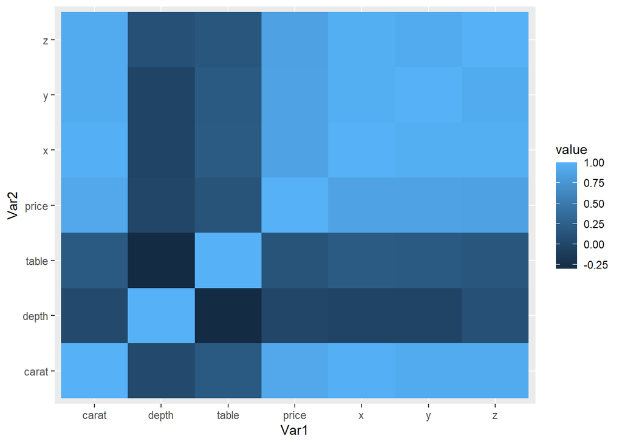

```r
ggplot(data = melted_corr_matrix, aes(x=Var1, y=Var2, fill=value)) +
  geom_tile()
```

In an effort to make this correlation matrix more readable, we can turn it into a heatmap. A heatmap is helpful, since it uses a different color negative and positive correlation. Also, the heatmap takes out the redundant info from the correlation matrix. We can also take the heatmap and make descisions of what columns to use and discard for the prediction models.

To convert our correlation matrix into a form that is helpful for the heatmap, we must define a couple of helper functions:

```r
# get the lower triangle of the matrix
calc_lower_Triangle <- function(corr_mat) {
  corr_mat[upper.tri(corr_mat)] <- NA
  return(corr_mat)
}

# get the upper triangle of the matrix
calc_upper_Triangle <- function(corr_mat) {
  corr_mat[lower.tri(corr_mat)] <- NA
  return(corr_mat)
}

# reordering a correlation matrix
reorder_matrix <- function(corr_mat) {
  dd <- as.dist((1 - corr_mat) / 2)
  hc <- hclust(dd)
  corr_mat <- corr_mat[hc$order, hc$order]
}
```

Now, we can create the final heat map for the dataset.

```r
# melt the upper triangle of the correlation matrix.
melted_corr_matrix <- melt(calc_upper_Triangle(corr_mat = corr_matrix), na.rm = TRUE)

# plot the resulting matrix as a heatmap
plot1 <- ggplot(data = melted_corr_matrix, aes(Var2, Var1, fill = value)) +
  geom_tile(color = "white") +
  scale_fill_gradient2(low = "blue", mid = "white", high = "red",       # setup the colors
                       midpoint = 0, limit = c(-1, 1), space = "Lab",   # setup the ranges
                       name="Diamond\nCorrelation") +                   # title of graph
  theme_minimal() + # setup the theme
  theme(axis.text.x = element_text(angle = 45, vjust = 1, size = 12, hjust = 1)) +
  coord_fixed()
```